# Assignment 1

### Problem 1

1. Explore the overall structure of the dataset using str(). When you read the data, set StringAsFactors=True to let R convert String variables to factors.

```r
vegas = read.table("data/LasVegasTripAdvisorReviews-Dataset.csv", sep=";",
                  header=TRUE, check.names=FALSE, stringsAsFactors=TRUE)
colnames(vegas) = gsub(" ", "", colnames(vegas))
#colnames(vegas) = gsub("\\.", "", colnames(vegas))
str(vegas)
```

```
'data.frame':   492 obs. of  20 variables:
 $ Usercountry    : Factor w/ 47 levels "Australia","Belgium",..: 47 47 47 45 4 4 45 47 17 4 ...
 $ Nr.reviews     : int  11 119 36 14 5 31 45 2 24 12 ...
 $ Nr.hotelreviews: int  4 21 9 7 5 8 12 1 3 7 ...
 $ Helpfulvotes   : int  13 75 25 14 2 27 46 4 8 11 ...
 $ Score          : int  5 3 5 4 4 3 4 4 4 3 ...
 $ Periodofstay   : Factor w/ 4 levels "Dec-Feb","Jun-Aug",..: 1 1 3 3 3 3 3 3 3 3 ...
 $ Travelertype   : Factor w/ 5 levels "Business","Couples",..: 4 1 3 4 5 2 2 3 4 3 ...
 $ Pool           : Factor w/ 2 levels "NO","YES": 1 1 1 1 1 1 1 1 1 1 ...
 $ Gym            : Factor w/ 2 levels "NO","YES": 2 2 2 2 2 2 2 2 2 2 ...
 $ Tenniscourt    : Factor w/ 2 levels "NO","YES": 1 1 1 1 1 1 1 1 1 1 ...
 $ Spa            : Factor w/ 2 levels "NO","YES": 1 1 1 1 1 1 1 1 1 1 ...
 $ Casino         : Factor w/ 2 levels "NO","YES": 2 2 2 2 2 2 2 2 2 2 ...
 $ Freeinternet   : Factor w/ 2 levels "NO","YES": 2 2 2 2 2 2 2 2 2 2 ...
 $ Hotelname      : Factor w/ 32 levels "Bellagio Las Vegas",..: 3 3 3 3 3 3 3 3 3 3 ...
 $ Hotelstars     : Factor w/ 5 levels "3","3,5","4",..: 1 1 1 1 1 1 1 1 1 1 ...
 $ Nr.rooms       : int  3773 3773 3773 3773 3773 3773 3773 3773 3773 3773 ...
 $ Usercontinent  : Factor w/ 6 levels "Africa","Asia",..: 4 4 4 3 4 4 3 4 2 4 ...
 $ Memberyears    : int  9 3 2 6 7 2 4 0 3 5 ...
 $ Reviewmonth    : Factor w/ 12 levels "April","August",..: 5 5 4 4 8 8 1 1 9 9 ...
 $ Reviewweekday  : Factor w/ 7 levels "Friday","Monday",..: 5 1 3 1 6 6 1 6 3 6 ...
```

2. Does any of the variables have missing values? It appears no columns have missing values.

```r
colSums(is.na(vegas))
```

```
    Usercountry      Nr.reviews Nr.hotelreviews    Helpfulvotes           Score
              0               0               0               0               0
   Periodofstay    Travelertype            Pool             Gym     Tenniscourt
              0               0               0               0               0
            Spa          Casino    Freeinternet       Hotelname      Hotelstars
              0               0               0               0               0
       Nr.rooms   Usercontinent     Memberyears     Reviewmonth   Reviewweekday
              0               0               0               0               0
```

```r
apply(is.na(vegas), 2, which)
```

```
integer(0)
```

```r
(1-mean(complete.cases(vegas)))
```

```
[1] 0
```

3. Draw a histogram of the score variable. Interpret the histogram: The Score data plotted indicates a majority of reviewers ranked their stays above 3. A very small proportion of reviews rated their stay as a 1 or 2. Additionally, a histogram may not be the best way to interpret score data because it limits the meaning of the scores and its relation to other variables.

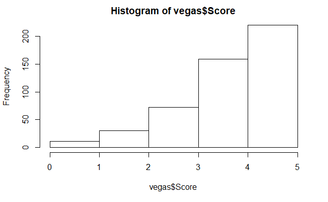

```r
hist(vegas$Score, breaks=c(0:5))
```

4. Find the mode of “Score”

```r
t = table(vegas$Score)
names(t[t == max(t)])
```

```
[1] "5"
```

5. Use the “quantile” function to get the quantiles for score. What is the median of score?

```r
quantile(vegas$Score, .25)
```

```
25%
  4
```

```r
quantile(vegas$Score, .5)
```

```
50%
  4
```

```r
quantile(vegas$Score, .75)
```

```
75%
  5
```

```r
median(vegas$Score)
```

```
[1] 4
```

6. Use the ifelse function (You can get help on the syntax of this function in R by typing ?ifelse) to create a factor variable “sentiment” which takes  
   the value “positive” if score is 4 or 5 and “negative” otherwise. You can use the method “factor” to create a factor from a character vector. Take a summary of “sentiment” to make sure that the frequencies of “positive” and “negative” categories are consistent with the frequency of the values  
   in Score.

```r
vegas$sentiment = ifelse(vegas$Score %in% c(4,5), "positive", "negative")
summary(vegas$sentiment)
```

```
   Length     Class      Mode
      492 character character
```

```r
ftable(vegas$sentiment)
```

```
 negative positive

      113      379
```

```r
ftable(vegas$Score)
```

```
   1   2   3   4   5

  11  30  72 159 220
```

7. Use a statistical test to determine if sentiment is associated with any of the variables: “Pool”, “Gym”,“Free.Internet”, “Period.of.Stay”, “traverler.type”“, and”hotel.stars" (Assume the significance level alpha=0.01). Which of these variables are associated with sentiment?

- sentiment/Pool - p-value is less than alpha, we can conclude dependence. Reject null.
- sentiment/Gym - p-value is greater than alpha, we cannot reject null. Can’t conclude they are not independent.
- sentiment/Free.Internet - p-value is less than alpha, we can conclude dependence. Reject null.
- sentiment/Period.of.Stay - p-value is greater than alpha, we cannot reject null. Can’t conclude they are not independent.
- sentiment/Traveler.type - p-value is greater than alpha, we cannot reject null. Can’t conclude they are not independent.
- sentiment/Hotel.stars - p-value is less than alpha, we can conclude dependence. Reject null.

```r
library(gmodels)
# CrossTable(x = vegas$sentiment, y = vegas$Pool)
chisq.test(vegas$sentiment, vegas$Pool)
```

```
    Pearson's Chi-squared test with Yates' continuity correction

data:  vegas$sentiment and vegas$Pool
X-squared = 12.089, df = 1, p-value = 0.0005071
```

```r
# CrossTable(x = vegas$sentiment, y = vegas$Gym)
chisq.test(vegas$sentiment, vegas$Gym)
```

```
    Pearson's Chi-squared test with Yates' continuity correction

data:  vegas$sentiment and vegas$Gym
X-squared = 0.0000000000000000000000000000035327, df = 1, p-value = 1
```

```r
# CrossTable(x = vegas$sentiment, y = vegas$Freeinternet)
chisq.test(vegas$sentiment, vegas$Freeinternet)
```

```
    Pearson's Chi-squared test with Yates' continuity correction

data:  vegas$sentiment and vegas$Freeinternet
X-squared = 8.8768, df = 1, p-value = 0.002888
```

```r
# CrossTable(x = vegas$sentiment, y = vegas$Periodofstay)
chisq.test(vegas$sentiment, vegas$Periodofstay)
```

```
    Pearson's Chi-squared test

data:  vegas$sentiment and vegas$Periodofstay
X-squared = 2.9799, df = 3, p-value = 0.3947
```

```r
# CrossTable(x = vegas$sentiment, y = vegas$Travelertype)
chisq.test(vegas$sentiment, vegas$Travelertype)
```

```
    Pearson's Chi-squared test

data:  vegas$sentiment and vegas$Travelertype
X-squared = 9.8834, df = 4, p-value = 0.04244
```

```r
#CrossTable(x = vegas$sentiment, y = vegas$Hotelstars)
chisq.test(vegas$sentiment, vegas$Hotelstars)
```

```
    Pearson's Chi-squared test

data:  vegas$sentiment and vegas$Hotelstars
X-squared = 32.275, df = 4, p-value = 0.000001681
```

### Problem 2

1. Explore the structure of dataset. How many numerical and categorical attributes are there in the dataset: 9 numeric, 1 categoric (ocean_proximitiy)

```r
house = read.csv("data/housing-1.csv")
str(house)
```

```
'data.frame':   20640 obs. of  10 variables:
 $ longitude         : num  -122 -122 -122 -122 -122 ...
 $ latitude          : num  37.9 37.9 37.9 37.9 37.9 ...
 $ housing_median_age: num  41 21 52 52 52 52 52 52 42 52 ...
 $ total_rooms       : num  880 7099 1467 1274 1627 ...
 $ total_bedrooms    : num  129 1106 190 235 280 ...
 $ population        : num  322 2401 496 558 565 ...
 $ households        : num  126 1138 177 219 259 ...
 $ median_income     : num  8.33 8.3 7.26 5.64 3.85 ...
 $ median_house_value: num  452600 358500 352100 341300 342200 ...
 $ ocean_proximity   : Factor w/ 5 levels "<1H OCEAN","INLAND",..: 4 4 4 4 4 4 4 4 4 4 ...
```

2. Take a summary statistics of the dataset.Does any of the variables have missing values? total_bedrooms has missing values

```r
summary(house)
```

```
   longitude         latitude     housing_median_age  total_rooms    total_bedrooms
 Min.   :-124.3   Min.   :32.54   Min.   : 1.00      Min.   :    2   Min.   :   1.0
 1st Qu.:-121.8   1st Qu.:33.93   1st Qu.:18.00      1st Qu.: 1448   1st Qu.: 296.0
 Median :-118.5   Median :34.26   Median :29.00      Median : 2127   Median : 435.0
 Mean   :-119.6   Mean   :35.63   Mean   :28.64      Mean   : 2636   Mean   : 537.9
 3rd Qu.:-118.0   3rd Qu.:37.71   3rd Qu.:37.00      3rd Qu.: 3148   3rd Qu.: 647.0
 Max.   :-114.3   Max.   :41.95   Max.   :52.00      Max.   :39320   Max.   :6445.0
                                                                     NA's   :207
   population      households     median_income     median_house_value   ocean_proximity
 Min.   :    3   Min.   :   1.0   Min.   : 0.4999   Min.   : 14999     <1H OCEAN :9136
 1st Qu.:  787   1st Qu.: 280.0   1st Qu.: 2.5634   1st Qu.:119600     INLAND    :6551
 Median : 1166   Median : 409.0   Median : 3.5348   Median :179700     ISLAND    :   5
 Mean   : 1425   Mean   : 499.5   Mean   : 3.8707   Mean   :206856     NEAR BAY  :2290
 3rd Qu.: 1725   3rd Qu.: 605.0   3rd Qu.: 4.7432   3rd Qu.:264725     NEAR OCEAN:2658
 Max.   :35682   Max.   :6082.0   Max.   :15.0001   Max.   :500001
```

```r
apply(house, 2, function(col)sum(is.na(col)))
```

```
         longitude           latitude housing_median_age        total_rooms
                 0                  0                  0                  0
    total_bedrooms         population         households      median_income
               207                  0                  0                  0
median_house_value    ocean_proximity
                 0                  0
```

```r
colMeans(is.na(house))
```

```
         longitude           latitude housing_median_age        total_rooms
        0.00000000         0.00000000         0.00000000         0.00000000
    total_bedrooms         population         households      median_income
        0.01002907         0.00000000         0.00000000         0.00000000
median_house_value    ocean_proximity
        0.00000000         0.00000000
```

3. What percentage of the rows have missing values in one or more variables? You can use the function “complete.cases” to get a logical vector indicating whether each row is complete (has no missing value) or incomplete (has one or more missing values). Run ?complete.cases to get help on this function in R. Use the logical vector returned by complete.cases to count the number of incomplete cases. ~1% of the rows have missing values.

```r
?complete.cases
z = apply(house, 2, function(col)complete.cases(col))
summary(z)
```

```
 longitude      latitude       housing_median_age total_rooms    total_bedrooms
 Mode:logical   Mode:logical   Mode:logical       Mode:logical   Mode :logical
 TRUE:20640     TRUE:20640     TRUE:20640         TRUE:20640     FALSE:207
                                                                 TRUE :20433
 population     households     median_income  median_house_value ocean_proximity
 Mode:logical   Mode:logical   Mode:logical   Mode:logical       Mode:logical
 TRUE:20640     TRUE:20640     TRUE:20640     TRUE:20640         TRUE:20640
```

```r
(1-mean(complete.cases(house)))
```

```
[1] 0.01002907
```

4. Remove the rows with missing values. You can use either “complete.cases” function or “na.omit” function for this purpose. Run ?na.omit in R to get help on these functions and to see some examples.

```r
house = house[complete.cases(house$total_bedrooms),]
```

5. Draw a histogram and boxplot of the median_house_value. What can you say about the shape of median_house_value? Is the median_house_value sample positively skewed, symmetric, or negatively skewed? median_house_value is right-tailed or positively skewed.

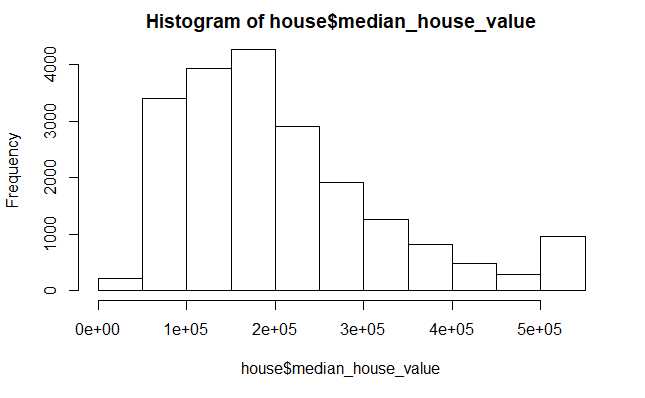

```r
options(scipen=999) # disable scientific notation
hist(house$median_house_value)
```

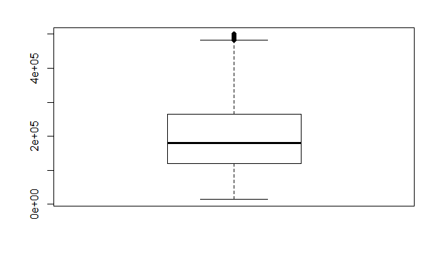

```r
boxplot(house$median_house_value)
```

6. Use Q-Q plot to examine if the distribution of median_house_value is approximately normal? It is not. the plot should be approximately straight and diagonal from left to right.

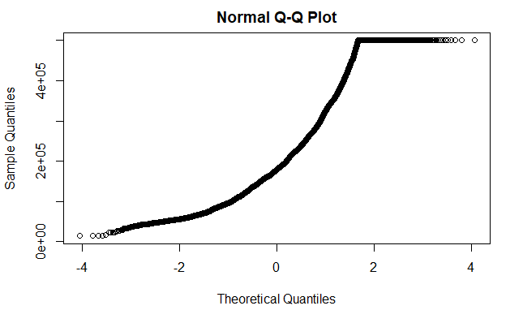

```r
options(scipen=999) # disable scientific notation
qqnorm(house$median_house_value)
```

7. Use IQR method to find outliers of the median_house_value attribute. How many outliers does this attribute have? ~1064 items are outliers.

```r
### House median_house_value outliers
iqr <- IQR(house$median_house_value)
q1 <- quantile(house$median_house_value, .25)
q3 <- quantile(house$median_house_value, .75)
leftvalue <- q1-1.5*iqr
rightvalue <- q3+1.5*iqr
house[house$median_house_value<leftvalue |
           house$median_house_value>rightvalue,]
```

|  | longitude | latitude | housing_median_age | total_rooms | total_bedrooms | population | households | median_income | median_house_value | ocean_proximity |
| --- | --- | --- | --- | --- | --- | --- | --- | --- | --- | --- |
| 90 | -122.27 | 37.80 | 52 | 249 | 78 | 396 | 85 | 1.2434 | 500001 | NEAR BAY |
| 141 | -122.18 | 37.81 | 30 | 292 | 38 | 126 | 52 | 6.3624 | 483300 | NEAR BAY |
| 460 | -122.25 | 37.87 | 52 | 609 | 236 | 1349 | 250 | 1.1696 | 500001 | NEAR BAY |
| 490 | -122.25 | 37.86 | 48 | 2153 | 517 | 1656 | 459 | 3.0417 | 489600 | NEAR BAY |
| 494 | -122.24 | 37.86 | 52 | 1668 | 225 | 517 | 214 | 7.8521 | 500001 | NEAR BAY |
| 495 | -122.24 | 37.85 | 52 | 3726 | 474 | 1366 | 496 | 9.3959 | 500001 | NEAR BAY |
| 510 | -122.23 | 37.83 | 52 | 2990 | 379 | 947 | 361 | 7.8772 | 500001 | NEAR BAY |
| 511 | -122.22 | 37.82 | 39 | 2492 | 310 | 808 | 315 | 11.8603 | 500001 | NEAR BAY |
| 512 | -122.22 | 37.82 | 42 | 2991 | 335 | 1018 | 335 | 13.4990 | 500001 | NEAR BAY |
| 513 | -122.23 | 37.82 | 52 | 3242 | 366 | 1001 | 352 | 12.2138 | 500001 | NEAR BAY |

[output cut: 990 more lines]

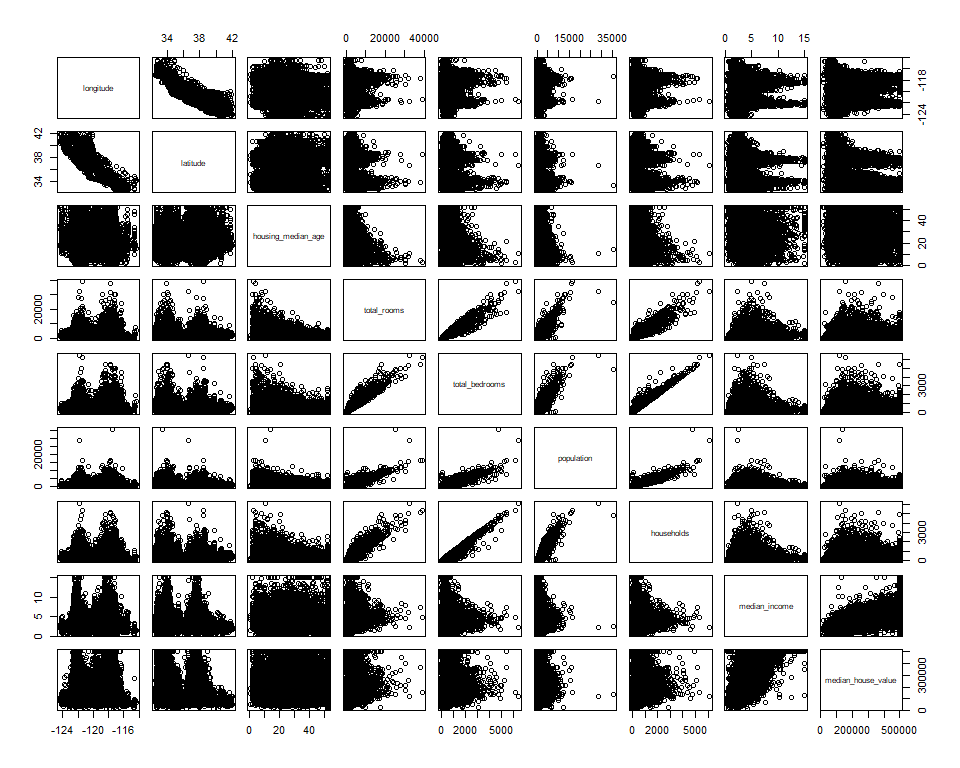

```r
numeric_att = house[, c("longitude", "latitude", "housing_median_age",
                        "total_rooms", "total_bedrooms", "population",
                        "households", "median_income", "median_house_value")]
pairs(numeric_att)
```

```r
cor(numeric_att)
```

```
                     longitude    latitude housing_median_age total_rooms total_bedrooms
longitude           1.00000000 -0.92461611        -0.10935655  0.04548017     0.06960802
latitude           -0.92461611  1.00000000         0.01189907 -0.03666681    -0.06698283
housing_median_age -0.10935655  0.01189907         1.00000000 -0.36062830    -0.32045104
total_rooms         0.04548017 -0.03666681        -0.36062830  1.00000000     0.93037950
total_bedrooms      0.06960802 -0.06698283        -0.32045104  0.93037950     1.00000000
population          0.10027030 -0.10899734        -0.29578730  0.85728125     0.87774674
households          0.05651277 -0.07177419        -0.30276797  0.91899153     0.97972827
median_income      -0.01555015 -0.07962632        -0.11827772  0.19788152    -0.00772285
median_house_value -0.04539822 -0.14463821         0.10643205  0.13329413     0.04968618
                     population  households median_income median_house_value
longitude           0.100270301  0.05651277  -0.015550150        -0.04539822
latitude           -0.108997344 -0.07177419  -0.079626319        -0.14463821
housing_median_age -0.295787297 -0.30276797  -0.118277723         0.10643205
total_rooms         0.857281251  0.91899153   0.197881519         0.13329413
total_bedrooms      0.877746743  0.97972827  -0.007722850         0.04968618
population          1.000000000  0.90718590   0.005086624        -0.02529973
households          0.907185900  1.00000000   0.013433892         0.06489355
median_income       0.005086624  0.01343389   1.000000000         0.68835548
median_house_value -0.025299732  0.06489355   0.688355475         1.00000000
```

9. Is there a statistically significant difference between the mean of meadian_house_value across different levels of ocean_proximity ? Use an appropriate plot and statistical test (with significance level alpha=0.01) to answerthis question. We can reject the null and there is a statistically significant difference between the means. Visually, ISLAND has a much higher mean value than the other levels.. INLAND has a much lower mean value than the other levels.

```r
levels(house$ocean_proximity)
```

```
[1] "<1H OCEAN"  "INLAND"     "ISLAND"     "NEAR BAY"   "NEAR OCEAN"
```

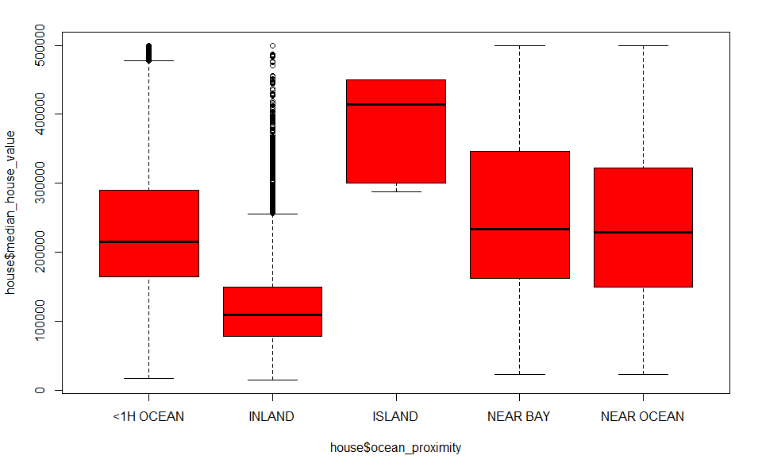

```r
plot(house$median_house_value~house$ocean_proximity, col="red")
```

```r
oneway.test(house$median_house_value~house$ocean_proximity, data=house)
```

```
    One-way analysis of means (not assuming equal variances)

data:  house$median_house_value and house$ocean_proximity
F = 2055.8, num df = 4.000, denom df = 31.918, p-value < 0.00000000000000022
```

10. Use ifelse function to create a new factor variable “Is_Inland” which takes the value “Yes” if the ocean_proximity is “Inland” and No” otherwise.

```r
house$Is_Inland = as.factor(ifelse(house$ocean_proximity == "INLAND",
                                   "Yes", "No"))
```

11. Use side by side box plot to visualize the relationship between “Is_Inland” and “median_house_value”. Is there a significant difference between the means of median_house_value for Inland vs not Inland houses? Use an appropriate statistical test to answer this question ( use significance level alpha=0.01). Since the p-value is less than the alpha we can conclude there is a statistical difference between the means of median_house_value and Is_Inland.

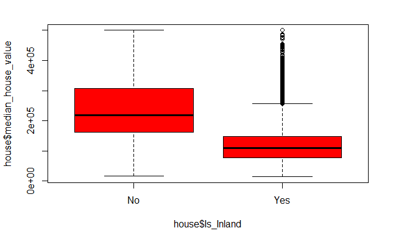

```r
plot(house$median_house_value~house$Is_Inland, col="red")
```

```r
t.test(house$median_house_value~house$Is_Inland, alternative="two.sided")
```

```
    Welch Two Sample t-test

data:  house$median_house_value by house$Is_Inland
t = 93.166, df = 18820, p-value < 0.00000000000000022
alternative hypothesis: true difference in means is not equal to 0
95 percent confidence interval:
 117644.1 122700.7
sample estimates:
 mean in group No mean in group Yes
         245069.3          124896.9
```

### Problem 3

1. Open these files and examine the data in them. Note that the files do not have a header and the missing values are marked by “?” character. Each file contains the 14 attributes described here. Load each file to a dataframe (remember to set na.string=”?” so that “?” is recognized as missing not a data value).

```r
cleveland = read.table("data/processed.cleveland.data", sep=",", na.string="?",
                   col.names=c("age", "sex", "cp", "trestbps", "chol", "fbs",
                               "restecg", "thalach", "exang", "oldpeak",
                               "slope", "ca", "thal", "num"))
hungarian = read.table("data/processed.hungarian.data", sep=",", na.string="?",
                   col.names=c("age", "sex", "cp", "trestbps", "chol", "fbs",
                               "restecg", "thalach", "exang", "oldpeak",
                               "slope", "ca", "thal", "num"))
switzerland = read.table("data/processed.switzerland.data", sep=",", na.string="?",
                   col.names=c("age", "sex", "cp", "trestbps", "chol", "fbs",
                               "restecg", "thalach", "exang", "oldpeak",
                               "slope", "ca", "thal", "num"))
va = read.table("data/processed.va.data", sep=",", na.string="?",
                   col.names=c("age", "sex", "cp", "trestbps", "chol", "fbs",
                               "restecg", "thalach", "exang", "oldpeak",
                               "slope", "ca", "thal", "num"))
```

2. Use rbind function to combine the four dataframes into one dataframe and manually set the column names using colnames function. The name of each column/attribute is described here.

```r
combined = rbind(cleveland, hungarian, switzerland, va)
```

3. Explore the overall structure of the dataset. What percentage of rows have missing values in one or more attributes?

```r
summary(combined)
```

```
      age             sex               cp          trestbps          chol
 Min.   :28.00   Min.   :0.0000   Min.   :1.00   Min.   :  0.0   Min.   :  0.0
 1st Qu.:47.00   1st Qu.:1.0000   1st Qu.:3.00   1st Qu.:120.0   1st Qu.:175.0
 Median :54.00   Median :1.0000   Median :4.00   Median :130.0   Median :223.0
 Mean   :53.51   Mean   :0.7891   Mean   :3.25   Mean   :132.1   Mean   :199.1
 3rd Qu.:60.00   3rd Qu.:1.0000   3rd Qu.:4.00   3rd Qu.:140.0   3rd Qu.:268.0
 Max.   :77.00   Max.   :1.0000   Max.   :4.00   Max.   :200.0   Max.   :603.0
                                                 NA's   :59      NA's   :30
      fbs            restecg          thalach          exang           oldpeak
 Min.   :0.0000   Min.   :0.0000   Min.   : 60.0   Min.   :0.0000   Min.   :-2.6000
 1st Qu.:0.0000   1st Qu.:0.0000   1st Qu.:120.0   1st Qu.:0.0000   1st Qu.: 0.0000
 Median :0.0000   Median :0.0000   Median :140.0   Median :0.0000   Median : 0.5000
 Mean   :0.1663   Mean   :0.6046   Mean   :137.5   Mean   :0.3896   Mean   : 0.8788
 3rd Qu.:0.0000   3rd Qu.:1.0000   3rd Qu.:157.0   3rd Qu.:1.0000   3rd Qu.: 1.5000
 Max.   :1.0000   Max.   :2.0000   Max.   :202.0   Max.   :1.0000   Max.   : 6.2000
 NA's   :90       NA's   :2        NA's   :55      NA's   :55       NA's   :62
     slope             ca              thal            num
 Min.   :1.000   Min.   :0.0000   Min.   :3.000   Min.   :0.0000
 1st Qu.:1.000   1st Qu.:0.0000   1st Qu.:3.000   1st Qu.:0.0000
 Median :2.000   Median :0.0000   Median :6.000   Median :1.0000
 Mean   :1.771   Mean   :0.6764   Mean   :5.088   Mean   :0.9957
 3rd Qu.:2.000   3rd Qu.:1.0000   3rd Qu.:7.000   3rd Qu.:2.0000
 Max.   :3.000   Max.   :3.0000   Max.   :7.000   Max.   :4.0000
 NA's   :309     NA's   :611      NA's   :486
```

```r
apply(combined, 2, function(col)sum(is.na(col)))
```

```
     age      sex       cp trestbps     chol      fbs  restecg  thalach    exang  oldpeak
       0        0        0       59       30       90        2       55       55       62
   slope       ca     thal      num
     309      611      486        0
```

```r
colMeans(is.na(combined)) # missing values by column
```

```
        age         sex          cp    trestbps        chol         fbs     restecg
0.000000000 0.000000000 0.000000000 0.064130435 0.032608696 0.097826087 0.002173913
    thalach       exang     oldpeak       slope          ca        thal         num
0.059782609 0.059782609 0.067391304 0.335869565 0.664130435 0.528260870 0.000000000
```

```r
mean(is.na(combined)) # total of all rows/columns
```

```
[1] 0.1365683
```

```r
(1-mean(complete.cases(combined))) # percent rows with a missing value
```

```
[1] 0.675
```

4. Read the data description carefully. Decide which attributes are categorical and convert them to “factor” using factor function (set the “labels” option to give meaningful names/labels to each level)

```r
combined$sex = factor(combined$sex, levels=c(1,0), labels=c("Male", "Female"))
combined$cp = factor(combined$cp, levels=c(1,2,3,4),
                     labels=c("typical angina", "atypical angina",
                              "non-anginal pain", "asymptomatic"))
combined$fbs = factor(combined$fbs, levels=c(1,0),
                      labels=c("fbs > 120mg/dl", "fbs < 120mg/dl"))
combined$restecg = factor(combined$restecg, levels=c(0,1,2),
                          labels=c("normal", "ST-T abnormality",
                                   "prob/def left     ventricular hypertrophy"))
combined$exang = factor(combined$exang, levels=c(1,0),
                        labels=c("exercise induced angina",
                                 "no exercise induced angina"))
combined$slope = factor(combined$slope, levels=c(1,2,3),
                        labels=c("upsloping ST seg", "flat ST seg",
                                 "downloping ST seg"))
combined$ca = factor(combined$ca, levels=c(0,1,2,3),
                     labels("1 fluoro vessel, 2 fluoro vessel", "3 fluoro
                            vessel", "4 fluoro vessel"))
combined$thal = factor(combined$thal, levels=c(3,6,7),
                       labels=c("normal", "fixed defect", "reversable defect"))
```

5. What is the median and mode of the age attribute. 54 and 54

```r
median(combined$age)
```

```
[1] 54
```

```r
t = table(combined$age)
names(t[t == max(t)])
```

```
[1] "54"
```

6. Are female patients under-represented compared to male patients in this dataset? Yes

```r
table(combined$sex)
```

```
  Male Female
   726    194
```

7. Use “ifelse” and “factor” functions to create a new factor variable (call it  
   “diagnosis”) which takes the value “No” if column 14 has the value zero and “Yes” otherwise. Replace column 14 of your dataframe with this new variable.

```r
combined$diagnosis = factor(ifelse(combined$num == 0, "No", "Yes"))
combined[,"num"] = NULL
```

8. Explore the relationship between “diagnosis” variable and all other 13 attributes in the dataset. Which variables are associated with “diagnosis” use appropriate plots and statistical tests to answer this question.

p-value is significantly smaller than the critical value in all variables. Association: age, sex, cp, fbs, restecg, exang, slope, ca, and thal, trestbps, chol, thalach, oldpeak -

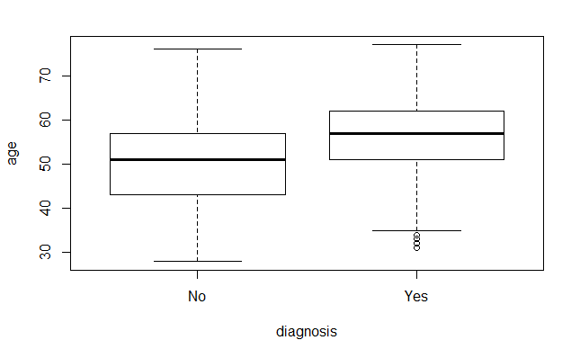

```r
library(gmodels)
attach(combined)
options(scipen=999)
# Numeric
plot(age~diagnosis)
```

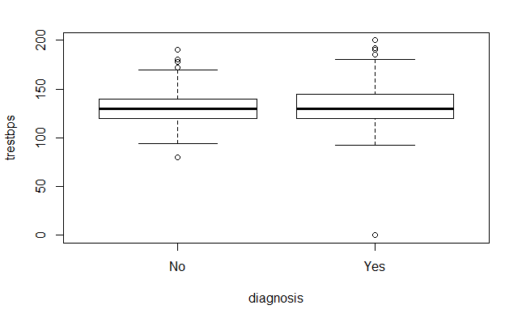

```r
plot(trestbps~diagnosis)
```

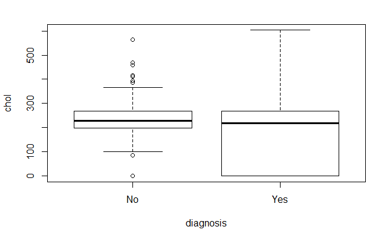

```r
plot(chol~diagnosis)
```

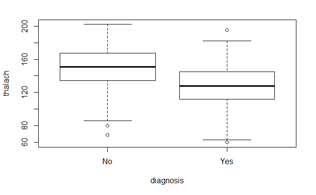

```r
plot(thalach~diagnosis)
```

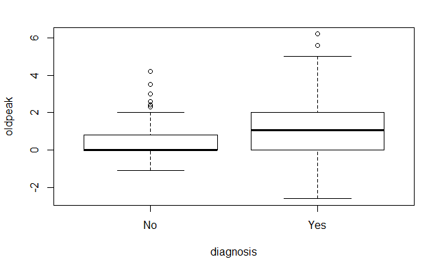

```r
plot(oldpeak~diagnosis)
```

```r
# 2-level test on diagnosis
t.test(age~diagnosis, alternative="two.sided")
```

```
    Welch Two Sample t-test

data:  age by diagnosis
t = -8.8551, df = 845.86, p-value < 0.00000000000000022
alternative hypothesis: true difference in means is not equal to 0
95 percent confidence interval:
 -6.543537 -4.169039
sample estimates:
 mean in group No mean in group Yes
         50.54745          55.90373
```

```r
t.test(trestbps~diagnosis, alternative="two.sided")
```

```
    Welch Two Sample t-test

data:  trestbps by diagnosis
t = -3.1878, df = 858.85, p-value = 0.001485
alternative hypothesis: true difference in means is not equal to 0
95 percent confidence interval:
 -6.56889 -1.56247
sample estimates:
 mean in group No mean in group Yes
         129.9130          133.9787
```

```r
t.test(chol~diagnosis, alternative="two.sided")
```

```
    Welch Two Sample t-test

data:  chol by diagnosis
t = 7.4756, df = 830.75, p-value = 0.0000000000001951
alternative hypothesis: true difference in means is not equal to 0
95 percent confidence interval:
 37.92323 64.92815
sample estimates:
 mean in group No mean in group Yes
         227.9056          176.4799
```

```r
t.test(thalach~diagnosis, alternative="two.sided")
```

```
    Welch Two Sample t-test

data:  thalach by diagnosis
t = 12.633, df = 837.18, p-value < 0.00000000000000022
alternative hypothesis: true difference in means is not equal to 0
95 percent confidence interval:
 17.34784 23.72998
sample estimates:
 mean in group No mean in group Yes
         148.8005          128.2616
```

```r
t.test(oldpeak~diagnosis, alternative="two.sided")
```

```
    Welch Two Sample t-test

data:  oldpeak by diagnosis
t = -12.763, df = 780.9, p-value < 0.00000000000000022
alternative hypothesis: true difference in means is not equal to 0
95 percent confidence interval:
 -0.9742705 -0.7145329
sample estimates:
 mean in group No mean in group Yes
        0.4182051         1.2626068
```

```r
# Categoric
table(diagnosis, sex)
```

```
         sex
diagnosis Male Female
      No   267    144
      Yes  459     50
```

```r
chisq.test(table(diagnosis, sex))
```

```
    Pearson's Chi-squared test with Yates' continuity correction

data:  table(diagnosis, sex)
X-squared = 85.361, df = 1, p-value < 0.00000000000000022
```

```r
table(diagnosis, cp)
```

```
         cp
diagnosis typical angina atypical angina non-anginal pain asymptomatic
      No              26             150              131          104
      Yes             20              24               73          392
```

```r
chisq.test(table(diagnosis, cp))
```

```
    Pearson's Chi-squared test

data:  table(diagnosis, cp)
X-squared = 268.35, df = 3, p-value < 0.00000000000000022
```

```r
table(diagnosis, fbs)
```

```
         fbs
diagnosis fbs > 120mg/dl fbs < 120mg/dl
      No              44            353
      Yes             94            339
```

```r
chisq.test(table(diagnosis, fbs))
```

```
    Pearson's Chi-squared test with Yates' continuity correction

data:  table(diagnosis, fbs)
X-squared = 16.112, df = 1, p-value = 0.00005972
```

```r
table(diagnosis, restecg)
```

```
         restecg
diagnosis normal ST-T abnormality prob/def left     ventricular hypertrophy
      No     268               61                                        82
      Yes    283              118                                       106
```

```r
chisq.test(table(diagnosis, restecg))
```

```
    Pearson's Chi-squared test

data:  table(diagnosis, restecg)
X-squared = 11.712, df = 2, p-value = 0.002863
```

```r
table(diagnosis, exang)
```

```
         exang
diagnosis exercise induced angina no exercise induced angina
      No                       55                        336
      Yes                     282                        192
```

```r
chisq.test(table(diagnosis, exang))
```

```
    Pearson's Chi-squared test with Yates' continuity correction

data:  table(diagnosis, exang)
X-squared = 184.02, df = 1, p-value < 0.00000000000000022
```

```r
table(diagnosis, slope)
```

```
         slope
diagnosis upsloping ST seg flat ST seg downloping ST seg
      No               125          79                14
      Yes               78         266                49
```

```r
chisq.test(table(diagnosis, slope))
```

```
    Pearson's Chi-squared test

data:  table(diagnosis, slope)
X-squared = 88.852, df = 2, p-value < 0.00000000000000022
```

```r
table(diagnosis, ca)
```

```
         ca
diagnosis  11  12  13  14
      No  133  21   8   3
      Yes  48  46  33  17
```

```r
chisq.test(table(diagnosis, ca))
```

```
    Pearson's Chi-squared test

data:  table(diagnosis, ca)
X-squared = 73.2, df = 3, p-value = 0.0000000000000008806
```

```r
table(diagnosis, thal)
```

```
         thal
diagnosis normal fixed defect reversable defect
      No     138           11                38
      Yes     58           35               154
```

```r
chisq.test(table(diagnosis, thal))
```

```
    Pearson's Chi-squared test

data:  table(diagnosis, thal)
X-squared = 109.05, df = 2, p-value < 0.00000000000000022
```